# BA_HW2

Conclusion: Chris Estimation is fairly accurate enough. Hence, Chris is right.

2. Build a model that uses the number of cylinders (cyl) and the mile per gallon (mpg) values of a car to predict the car Horse Power (hp).
1. Using this model, what is the estimated Horse Power of a car with 4 calendar and mpg of 22? (5 mark)
2. Construct an 85% confidence interval of your answer in the above question. Hint: use the predict function (5 mark)

```r
Model3<-lm(hp~cyl+mpg,data = mtcars)
summary(Model3)
```

```
##
## Call:
## lm(formula = hp ~ cyl + mpg, data = mtcars)
##
## Residuals:
##    Min     1Q Median     3Q    Max
## -53.72 -22.18 -10.13  14.47 130.73
##
## Coefficients:
##             Estimate Std. Error t value Pr(>|t|)
## (Intercept)   54.067     86.093   0.628  0.53492
## cyl           23.979      7.346   3.264  0.00281 **
## mpg           -2.775      2.177  -1.275  0.21253
## ---
## Signif. codes:  0 '***' 0.001 '**' 0.01 '*' 0.05 '.' 0.1 ' ' 1
##
## Residual standard error: 38.22 on 29 degrees of freedom
## Multiple R-squared:  0.7093, Adjusted R-squared:  0.6892
## F-statistic: 35.37 on 2 and 29 DF,  p-value: 1.663e-08
```

```r
estimated_HP<-predict(Model3,data.frame(cyl=4,mpg=22))
estimated_HP
```

```
##        1
## 88.93618
```

```r
predict(Model3,data.frame(cyl=4,mpg=22),interval = "prediction",level = 0.85)
```

```
##        fit      lwr      upr
## 1 88.93618 28.53849 149.3339
```

3. For this question, we are going to use BostonHousing dataset. The dataset is in ‘mlbench’ package, so we first need to install the package, call the library and load the dataset using the following commands

```r
#install.packages('mlbench')
library(mlbench)
data(BostonHousing)
str(BostonHousing)
```

```
## 'data.frame':    506 obs. of  14 variables:
##  $ crim   : num  0.00632 0.02731 0.02729 0.03237 0.06905 ...
##  $ zn     : num  18 0 0 0 0 0 12.5 12.5 12.5 12.5 ...
##  $ indus  : num  2.31 7.07 7.07 2.18 2.18 2.18 7.87 7.87 7.87 7.87 ...
##  $ chas   : Factor w/ 2 levels "0","1": 1 1 1 1 1 1 1 1 1 1 ...
##  $ nox    : num  0.538 0.469 0.469 0.458 0.458 0.458 0.524 0.524 0.524 0.524 ...
##  $ rm     : num  6.58 6.42 7.18 7 7.15 ...
##  $ age    : num  65.2 78.9 61.1 45.8 54.2 58.7 66.6 96.1 100 85.9 ...
##  $ dis    : num  4.09 4.97 4.97 6.06 6.06 ...
##  $ rad    : num  1 2 2 3 3 3 5 5 5 5 ...
##  $ tax    : num  296 242 242 222 222 222 311 311 311 311 ...
##  $ ptratio: num  15.3 17.8 17.8 18.7 18.7 18.7 15.2 15.2 15.2 15.2 ...
##  $ b      : num  397 397 393 395 397 ...
##  $ lstat  : num  4.98 9.14 4.03 2.94 5.33 ...
##  $ medv   : num  24 21.6 34.7 33.4 36.2 28.7 22.9 27.1 16.5 18.9 ...
```

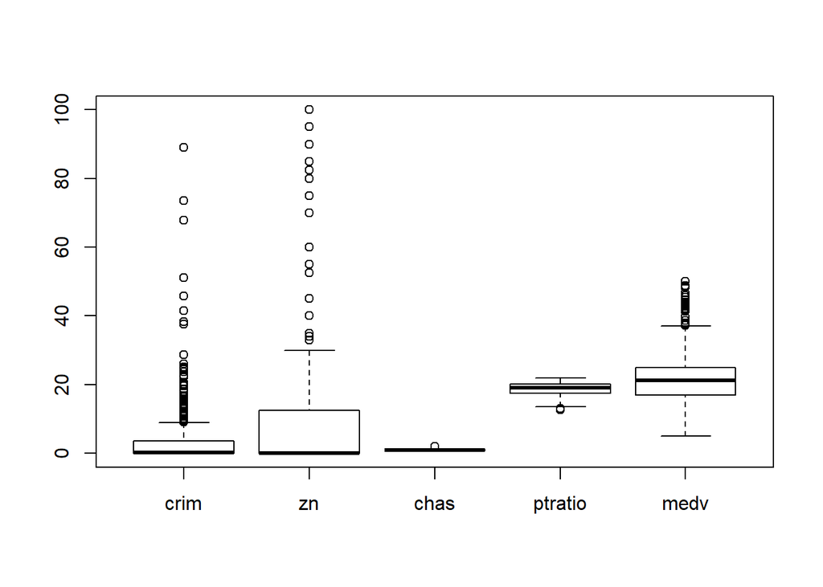

```r
#Let’s look at the variation in the values of various variables present in the dataset. This is achieved by plotting a boxplot of all the variables.
boxplot(BostonHousing[,c(1,2,4,11,14)])
```

1. Build a model to estimate the median value of owner-occupied homes (medv)based on the following variables: crime crate (crim), proportion of residential land zoned for lots over 25,000 sq.ft (zn), the local pupil-teacher ratio (ptratio) and weather the whether the tract bounds Chas River(chas). Is this an accurate model? (Hint check R2 ) (5 marks)

```r
set.seed(123)
Model4<-lm(medv~crim+zn+ptratio+chas,data = BostonHousing)
summary(Model4)
```

```
##
## Call:
## lm(formula = medv ~ crim + zn + ptratio + chas, data = BostonHousing)
##
## Residuals:
##     Min      1Q  Median      3Q     Max
## -18.282  -4.505  -0.986   2.650  32.656
##
## Coefficients:
##             Estimate Std. Error t value Pr(>|t|)
## (Intercept) 49.91868    3.23497  15.431  < 2e-16 ***
## crim        -0.26018    0.04015  -6.480 2.20e-10 ***
## zn           0.07073    0.01548   4.570 6.14e-06 ***
## ptratio     -1.49367    0.17144  -8.712  < 2e-16 ***
## chas1        4.58393    1.31108   3.496 0.000514 ***
## ---
## Signif. codes:  0 '***' 0.001 '**' 0.01 '*' 0.05 '.' 0.1 ' ' 1
##
## Residual standard error: 7.388 on 501 degrees of freedom
## Multiple R-squared:  0.3599, Adjusted R-squared:  0.3547
## F-statistic: 70.41 on 4 and 501 DF,  p-value: < 2.2e-16
```

The Model Accuracy is 0.3599. The Model is not Accurate enough.

2. Use the estimated coefficient to answer these questions?
1. Imagine two houses that are identical in all aspects but one bounds the Chas River and the other does not. Which one is more expensive and by how much? (5 marks)

Answer: Chas is factor of two levels ‘0’ and ‘1’. The one bounds the chas river is represented with “1”, who don’t are with “0”.Coefficient of chas1 is 4.58393 and in the data description, it is given that the median value of owner-occupied homes is in 1000 dollars. when multiplied with coefficient, the result is 4583.93$ which is expensive

2. Imagine two houses that are identical in all aspects but in the neighborhood of one of them the pupil-teacher ratio is 15 and in the other one is 18. Which one is more expensive and by how much? (Golden Question: 10 extra marks if you answer)

Answer: For every single unit increase in ptratio, price of houses is decreased by 1.49367 i.e., 1493.67 (in thousands).If ptratio is 15, there will be a decrease of 15 * 1493.67= 22405.05. similarly if ptratio is 18 then there will be a decrease of 18 * 1493.67=26886.06.So if pt ratio is 15 expensive by $4481.01 when comapred to ptratio 18.

3. Which of the variables are statistically important (i.e. related to the house price)? Hint: use the p-values of the coefficients to answer.(5 mark)

Answer: Yes, the p-values of all the variables are not equal to zero that means that we can very comfortably reject the default null hypothesis i.e. there is no relationship between House price and other variables in the model. Hence, all the variables are statistically important.

4. Use the anova analysis and determine the order of importance of these four variables.(5 marks)

```r
anova(Model4)
```

|  | Df | Sum Sq | Mean Sq | F value | Pr(>F) |
| --- | --- | --- | --- | --- | --- |
| crim | 1 | 6440.7831 | 6440.78306 | 118.00683 | 7.902220e-25 |
| zn | 1 | 3554.3362 | 3554.33620 | 65.12189 | 5.252886e-15 |
| ptratio | 1 | 4709.5358 | 4709.53584 | 86.28724 | 4.738745e-19 |
| chas | 1 | 667.1868 | 667.18681 | 12.22407 | 5.136898e-04 |
| Residuals | 501 | 27344.4535 | 54.57975 | NA | NA |

Answer: We can see that the variability (sum squared) explained by the crim variable is significantly higher than other variables. We could guess this as adding the crim, significantly improved the model. Still we can see that a large portion of the variability is unexplained, that is shown by residuals.

The order of importance is crim, ptratio,zn, chas